# Pilcomayo River Basin Heavy Metal Contamination Assessment (2016-2024)

Spatiotemporal Analysis of Contamination Migration and Precipitation-Driven Transport Patterns

Author

Affiliation

River Remedy Research Team

AMTSK Environmental Monitoring Initiative

Published

July 23, 2025

**Executive Summary - Comprehensive Basin Assessment**

**Critical Contamination Findings:** **1 stations** exhibit critical contamination levels with **33 stations** requiring immediate intervention. **Worst contaminated station: Agropil** demonstrates **75.9x WHO standard exceedance**.

## Research Methodology & Scope

This comprehensive assessment integrates multi-year monitoring data across water quality, sediment contamination, and precipitation patterns to characterize heavy metal contamination dynamics in the Pilcomayo River Basin. The analysis employs spatiotemporal modeling to identify contamination sources, migration pathways, and precipitation-driven transport mechanisms.

### Analytical Framework

- **Spatial Coverage**: 45 monitoring stations with geographical coordinates
- **Temporal Range**: 2016-2024 for contamination data, 2008-2022 for precipitation analysis
- **Regulatory Standards**: WHO drinking water guidelines, EPA Class A standards, EU directives, USGS sediment criteria
- **Transport Analysis**: Precipitation-contamination correlation modeling and seasonal pattern assessment
- **Risk Assessment**: Multi-standard exceedance analysis with ecological impact evaluation

## Station Risk Characterization

### Critical Contamination Assessment

| Monitoring Station | Basin Position | Samples | Period | As (µg/L) | Pb (µg/L) | Cd (µg/L) | Hg (µg/L) | As Risk | lead_risk | Risk Level | Total Risk |
| --- | --- | --- | --- | --- | --- | --- | --- | --- | --- | --- | --- |
| Agropil | Downstream | 3 | 2021-2024 | 227.7 | 463 | 227.6 | 2.583 | 22.8 | 46.3 | Critical | 75.9 |
| Hacienda 9 de junio | Downstream | 3 | 2021-2024 | 169 | 403 | 142.2 | 1 | 16.9 | 40.3 | High | 47.4 |
| San Antonio - Potosí | Middle | 12 | 2016-2024 | 242.2 | 156.6 | 127 | 2.889 | 24.2 | 15.7 | High | 42.3 |
| Chuquiago | Downstream | 10 | 2016-2024 | 105.6 | 411.7 | 48.9 | 1.774 | 10.6 | 41.2 | High | 41.2 |
| Canutillos 3 | Middle | 1 | 2017-2017 | 405 | 13 | 36 | NA | 40.5 | 1.3 | High | 40.5 |
| Cotagaita | Middle | 9 | 2016-2024 | 159.9 | 347.7 | 118 | 2.043 | 16 | 34.8 | High | 39.3 |
| Meyer Sitio 01 | Downstream | 4 | 2021-2024 | 126.8 | 286.2 | 99.4 | 2.062 | 12.7 | 28.6 | High | 33.1 |
| Talula - Automática | Middle | 8 | 2022-2024 | 134.1 | 252.1 | 96.8 | 2.743 | 13.4 | 25.2 | High | 32.3 |
| Clorinda | Downstream | 8 | 2017-2024 | 7.9 | 308.9 | 4.1 | 1.164 | 0.8 | 30.9 | High | 30.9 |
| Ruta 95 | Downstream | 7 | 2017-2024 | 12.3 | 298.1 | 4.8 | 1.364 | 1.2 | 29.8 | High | 29.8 |

[output cut: 2 more lines]

## Spatiotemporal Contamination Analysis

### Contamination Migration Patterns

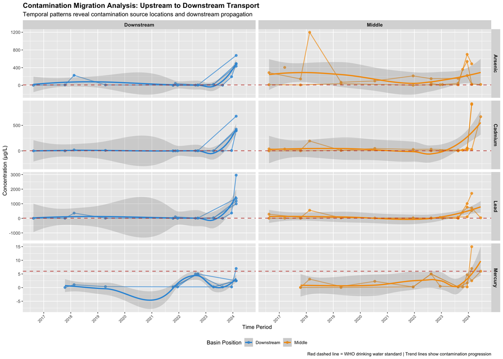

Individual station temporal trends revealing contamination events and downstream migration patterns

**Figure 1: Spatiotemporal Heavy Metal Contamination Patterns - High-Risk Station Analysis**